# EDA – Zdrowie psychiczne studentów (University Students’ Mental Health)

A.K.

2024-12-02

Pakiety, z których korzystam w analizie:

```r
library(readr)        # wczytywanie danych
library(dplyr)        # transformacje danych
library(tidyr)        # pivot_longer
library(stringr)      # czyszczenie tekstu
library(forcats)      # porządkowanie poziomów faktorów
library(ggplot2)      # wykresy
library(scales)       # formatowanie osi (procenty)
library(RColorBrewer) # palety kolorów
library(corrplot)     # macierz korelacji
library(knitr)        # tabele kable
library(kableExtra)   # stylizacja tabel
library(DT)           # interaktywny podgląd danych
```

# Wstęp

Celem tej analizy eksploracyjnej (EDA) jest zrozumienie struktury i rozkładu danych o zdrowiu psychicznym studentów zawartych w pliku `mentalhealth_dataset.csv` oraz udzielenie odpowiedzi na postawione pytania badawcze. Zbiór danych został zebrany za pomocą ankiety w formularzach Google wśród studentów jednego z uniwersytetów w Malezji i opisuje ich sytuację akademicką oraz stan zdrowia psychicznego. Zbiór liczy **1000 obserwacji i 16 zmiennych**.

Warto już na wstępie zaznaczyć, że próba jest **silnie niezrównoważona pod względem płci** (760 kobiet i 240 mężczyzn), co należy uwzględniać przy interpretacji wyników. Porównania między płciami opieram więc na odsetkach w obrębie każdej grupy, a nie na liczbach bezwzględnych.

## Wczytanie danych

```r
mentalhealth_raw <- read_csv("mentalhealth_dataset.csv", show_col_types = FALSE)
```

## Przygotowanie i czyszczenie danych

Surowe dane wymagają uporządkowania, zanim przejdę do analizy. Kolumna `Course` zawiera 48 niespójnych wartości (różnice wielkości liter i literówki, np. `Engineering`/`engin`), a `YearOfStudy` ma niespójną wielkość liter. Wszystkie konwersje typów wykonuję **raz** w jednym potoku, aby uniknąć powtarzania ich przy każdym pytaniu.

```r
# akronimy kierunków: zostają zapisane wielkimi literami (nie są title-case'owane)
akronimy <- c("BCS", "BIT", "KOE", "BENL", "KIRKHS", "ENM", "CTS", "TESL",
              "MHSC", "KENMS", "ALA", "KOP", "IT", "TAASL")

# funkcja czyszcząca nazwy kierunków (scala duplikaty, zachowuje akronimy)
clean_course <- function(x) {
  y  <- str_squish(x)
  yl <- str_to_lower(y)
  case_when(
    yl %in% c("engineering", "engine", "engin") ~ "Engineering",
    yl %in% c("koe")                            ~ "KOE",
    yl %in% c("psychology")                     ~ "Psychology",
    yl %in% c("law", "laws")                    ~ "Law",
    yl %in% c("benl")                           ~ "BENL",
    yl %in% c("kirkhs", "irkhs")                ~ "KIRKHS",
    yl %in% c("pendidikan islam")               ~ "Pendidikan Islam",
    yl %in% c("islamic education")              ~ "Islamic Education",
    yl %in% c("biomedical science")             ~ "Biomedical Science",
    yl %in% c("mathemathics", "mathematics")    ~ "Mathematics",
    yl %in% c("diploma tesl")                   ~ "Diploma TESL",
    yl %in% c("diploma nursing")                ~ "Diploma Nursing",
    yl %in% c("banking studies")                ~ "Banking Studies",
    yl %in% c("business administration")        ~ "Business Administration",
    yl %in% c("human resources")                ~ "Human Resources",
    yl %in% c("human sciences")                 ~ "Human Sciences",
    yl %in% c("marine science")                 ~ "Marine Science",
    yl %in% c("fiqh fatwa")                     ~ "Fiqh Fatwa",
    str_to_upper(y) %in% akronimy               ~ str_to_upper(y),
    TRUE                                        ~ str_to_title(y)
  )
}

mentalhealth_data <- mentalhealth_raw %>%
  mutate(
    # płeć: tylko dwie kategorie, z czytelnymi polskimi etykietami
    Gender = factor(Gender, levels = c("Female", "Male"),
                    labels = c("Kobieta", "Mężczyzna")),
    # kierunek: oczyszczony
    Course_clean = factor(clean_course(Course)),
    # rok studiów: ujednolicona wielkość liter, uporządkowany factor
    YearOfStudy = factor(str_to_title(str_squish(YearOfStudy)),
                         levels = c("Year 1", "Year 2", "Year 3", "Year 4"),
                         ordered = TRUE),
    # konwersje typów wykonane raz
    across(c(Depression, Anxiety, PanicAttack,
             SpecialistTreatment, HasMentalHealthSupport), as.integer),
    across(c(Age, CGPA, SleepQuality, StudyStressLevel,
             StudyHoursPerWeek, AcademicEngagement, SymptomFrequency_Last7Days),
           as.numeric),
    # wersje etykietowane (do wykresów); numeryczne oryginały zostają do korelacji i testów
    Stres_f = factor(StudyStressLevel, levels = 1:5, ordered = TRUE,
                     labels = c("1 (najniższy)", "2", "3", "4", "5 (najwyższy)")),
    Sen_f = factor(SleepQuality, levels = 1:5, ordered = TRUE,
                   labels = c("1 (bardzo zła)", "2", "3", "4", "5 (bardzo dobra)")),
    Wsparcie_f = factor(HasMentalHealthSupport, levels = c(0, 1),
                        labels = c("Bez wsparcia", "Ze wsparciem")),
    Panika_f = factor(PanicAttack, levels = c(0, 1),
                      labels = c("Brak ataków", "Ataki paniki"))
  ) %>%
  select(-Timestamp)   # mieszane formaty dat, nieużywane w analizie

# pomocnik: ogranicza dane do kierunków o wystarczającej liczebności (domyślnie n >= 20)
courses_min_n <- function(df, min_n = 20) {
  df %>%
    add_count(Course_clean, name = "n_kierunek") %>%
    filter(n_kierunek >= min_n) %>%
    mutate(Course_clean = fct_drop(Course_clean)) %>%
    select(-n_kierunek)
}
```

Czyszczenie redukuje liczbę kierunków z 48 do 37, z czego tylko 10 ma liczebność n ≥ 20. Tylko te kierunki wykorzystuję w wykresach na poziomie kierunku (pytania 5 i 8).

```r
# spójny motyw i paleta dla wszystkich wykresów
theme_set(theme_minimal(base_size = 12))
theme_update(
  plot.title    = element_text(face = "bold", size = 14),
  plot.subtitle = element_text(color = "grey35"),
  axis.title    = element_text(size = 12),
  legend.position = "top"
)
# paleta przyjazna osobom z zaburzeniami rozróżniania barw (Okabe-Ito)
pal_okabe <- c("#0072B2", "#D55E00", "#009E73", "#CC79A7",
               "#E69F00", "#56B4E9", "#F0E442", "#999999")
```

## Pierwsze wiersze danych

```r
DT::datatable(
  head(mentalhealth_raw, 10),
  options = list(scrollX = TRUE, dom = "t"),
  caption = "Pierwsze 10 wierszy surowego zbioru"
)
```

|  | Timestamp | Gender | Age | Course | YearOfStudy | CGPA | Depression | Anxiety | PanicAttack | SpecialistTreatment | SymptomFrequency_Last7Days | HasMentalHealthSupport | SleepQuality | StudyStressLevel | StudyHoursPerWeek | AcademicEngagement |
| --- | --- | --- | --- | --- | --- | --- | --- | --- | --- | --- | --- | --- | --- | --- | --- | --- |
| 1 | 13/7/2020 | Female | 24 | Biotechnology | Year 3 | 2.38 | 1 | 0 | 0 | 0 | 5 | 0 | 4 | 5 | 8 | 2 |
| 2 | 13/7/2020 | Female | 18 | Biotechnology | Year 3 | 4 | 0 | 1 | 0 | 0 | 0 | 0 | 4 | 4 | 13 | 5 |
| 3 | 13/7/2020 | Female | 25 | Biotechnology | Year 3 | 3.68 | 0 | 0 | 1 | 0 | 3 | 0 | 1 | 2 | 13 | 1 |
| 4 | 13/7/2020 | Female | 18 | Engineering | year 4 | 4 | 0 | 0 | 0 | 0 | 3 | 0 | 5 | 1 | 19 | 2 |
| 5 | 13/7/2020 | Female | 20 | Engineering | year 4 | 2 | 1 | 1 | 0 | 0 | 0 | 0 | 2 | 4 | 3 | 2 |
| 6 | 13/7/2020 | Female | 19 | Engineering | year 4 | 4 | 0 | 0 | 1 | 0 | 4 | 0 | 4 | 1 | 15 | 3 |
| 7 | 13/7/2020 | Female | 25 | Communication | Year 2 | 2 | 1 | 1 | 0 | 0 | 0 | 0 | 1 | 2 | 1 | 2 |
| 8 | 13/7/2020 | Female | 24 | Diploma Nursing | year 2 | 2.72 | 0 | 0 | 0 | 0 | 3 | 0 | 3 | 5 | 8 | 2 |
| 9 | 13/7/2020 | Female | 24 | Pendidikan Islam | Year 2 | 2.3 | 0 | 0 | 0 | 0 | 5 | 0 | 4 | 4 | 5 | 3 |
| 10 | 13/7/2020 | Female | 19 | Engineering | year 1 | 4 | 1 | 1 | 0 | 0 | 5 | 0 | 4 | 2 | 16 | 3 |

## Kontrola jakości danych

Zamiast surowego `str()` sprawdzam zwięźle kompletność i unikalność danych:

```r
# metryki liczone na surowym zbiorze (16 kolumn), przed dodaniem kolumn pochodnych
tibble::tibble(
  Metryka = c("Liczba wierszy", "Liczba kolumn",
              "Braki danych (NA)", "Zduplikowane wiersze"),
  Wartość = c(nrow(mentalhealth_raw), ncol(mentalhealth_raw),
              sum(is.na(mentalhealth_raw)),
              sum(duplicated(mentalhealth_raw)))
) %>%
  kable(caption = "Kontrola jakości danych") %>%
  kable_styling(bootstrap_options = c("striped", "hover"), full_width = FALSE)
```

Kontrola jakości danych

| Metryka | Wartość |
| --- | --- |
| Liczba wierszy | 1000 |
| Liczba kolumn | 16 |
| Braki danych (NA) | 0 |
| Zduplikowane wiersze | 0 |

Zbiór jest kompletny (brak wartości `NA`) i nie zawiera zduplikowanych wierszy, więc nie ma potrzeby imputacji ani usuwania duplikatów.

## Statystyki opisowe zmiennych numerycznych

Poniżej statystyki dla zmiennych ciągłych i porządkowych (Likerta). Zmienne binarne 0/1 (depresja, lęk, ataki paniki, leczenie, wsparcie) pomijam; ich odsetki podałam w słowniku zmiennych.

```r
mentalhealth_data %>%
  select(Age, CGPA, SymptomFrequency_Last7Days, SleepQuality,
         StudyStressLevel, StudyHoursPerWeek, AcademicEngagement) %>%
  summarise(across(everything(),
                   list(min = ~min(.x), mediana = ~median(.x),
                        średnia = ~round(mean(.x), 2), max = ~max(.x)),
                   .names = "{.col}__{.fn}")) %>%
  pivot_longer(everything(),
               names_to = c("Zmienna", ".value"), names_sep = "__") %>%
  kable(caption = "Statystyki opisowe zmiennych numerycznych") %>%
  kable_styling(bootstrap_options = c("striped", "hover"), full_width = FALSE)
```

Statystyki opisowe zmiennych numerycznych

| Zmienna | min | mediana | średnia | max |
| --- | --- | --- | --- | --- |
| Age | 18 | 21.00 | 21.40 | 25 |
| CGPA | 2 | 3.25 | 3.12 | 4 |
| SymptomFrequency_Last7Days | 0 | 3.00 | 3.50 | 7 |
| SleepQuality | 1 | 3.00 | 2.98 | 5 |
| StudyStressLevel | 1 | 3.00 | 3.04 | 5 |
| StudyHoursPerWeek | 1 | 9.00 | 9.75 | 19 |
| AcademicEngagement | 1 | 3.00 | 3.06 | 5 |

# Opis zmiennych

Poniżej znajduje się słownik wszystkich 16 zmiennych. Przy zmiennych `Timestamp`, `YearOfStudy` i `Course` zaznaczam, że w surowej postaci wymagają uporządkowania (zostało ono wykonane w sekcji *Przygotowanie i czyszczenie danych*).

```r
slownik_zmiennych <- tibble::tribble(
  ~Zmienna,                     ~Typ,               ~Opis,                                    ~`Wartości / Zakres`,
  "Timestamp",                  "chr",              "Data wypełnienia ankiety",               "Mieszane formaty (np. 13/7/2020, 2020-07-08); nieużywana",
  "Gender",                     "chr",              "Płeć uczestnika",                        "Female (760), Male (240), tylko 2 kategorie",
  "Age",                        "num",              "Wiek studenta",                          "18–25 (mediana 21)",
  "Course",                     "chr",              "Kierunek studiów",                       "48 surowych kategorii, niespójne, wymaga czyszczenia",
  "YearOfStudy",                "chr",              "Rok studiów",                            "Niespójna wielkość liter → Year 1–Year 4",
  "CGPA",                       "num",              "Średnia ocen (Cumulative GPA)",          "2.0–4.0 (skupienie przy 4.0)",
  "Depression",                 "int (0/1)",        "Objawy depresji",                        "0 = brak, 1 = występują (48,3%)",
  "Anxiety",                    "int (0/1)",        "Objawy lęku",                            "0 = brak, 1 = występują (47,4%)",
  "PanicAttack",                "int (0/1)",        "Ataki paniki",                           "0 = brak, 1 = występują (45,8%)",
  "SpecialistTreatment",        "int (0/1)",        "Leczenie specjalistyczne",               "0 = nie, 1 = tak (6,7%)",
  "SymptomFrequency_Last7Days", "int",              "Liczba dni z objawami (ost. 7 dni)",     "0–7 (rozkład ~jednostajny)",
  "HasMentalHealthSupport",     "int (0/1)",        "Dostęp do wsparcia psychologicznego",    "0 = brak, 1 = tak (6,7%)",
  "SleepQuality",               "int (Likert 1–5)", "Jakość snu",                             "1 (bardzo zła) – 5 (bardzo dobra)",
  "StudyStressLevel",           "int (Likert 1–5)", "Poziom stresu związanego ze studiami",   "1 (niski) – 5 (wysoki)",
  "StudyHoursPerWeek",          "int",              "Godziny nauki tygodniowo",               "1–19 (rozkład ~jednostajny)",
  "AcademicEngagement",         "int (Likert 1–5)", "Zaangażowanie w studia",                 "1 (niskie) – 5 (wysokie)"
)

kable(slownik_zmiennych,
      caption = "Słownik zmiennych zbioru mentalhealth_dataset.csv (1000 obserwacji, 16 zmiennych)") %>%
  kable_styling(bootstrap_options = c("striped", "hover", "condensed", "responsive"),
                full_width = FALSE, position = "center") %>%
  column_spec(1, bold = TRUE)
```

Słownik zmiennych zbioru mentalhealth_dataset.csv (1000 obserwacji, 16 zmiennych)

| Zmienna | Typ | Opis | Wartości / Zakres |
| --- | --- | --- | --- |
| Timestamp | chr | Data wypełnienia ankiety | Mieszane formaty (np. 13/7/2020, 2020-07-08); nieużywana |
| Gender | chr | Płeć uczestnika | Female (760), Male (240), tylko 2 kategorie |
| Age | num | Wiek studenta | 18–25 (mediana 21) |
| Course | chr | Kierunek studiów | 48 surowych kategorii, niespójne, wymaga czyszczenia |
| YearOfStudy | chr | Rok studiów | Niespójna wielkość liter → Year 1–Year 4 |
| CGPA | num | Średnia ocen (Cumulative GPA) | 2.0–4.0 (skupienie przy 4.0) |
| Depression | int (0/1) | Objawy depresji | 0 = brak, 1 = występują (48,3%) |
| Anxiety | int (0/1) | Objawy lęku | 0 = brak, 1 = występują (47,4%) |
| PanicAttack | int (0/1) | Ataki paniki | 0 = brak, 1 = występują (45,8%) |
| SpecialistTreatment | int (0/1) | Leczenie specjalistyczne | 0 = nie, 1 = tak (6,7%) |
| SymptomFrequency_Last7Days | int | Liczba dni z objawami (ost. 7 dni) | 0–7 (rozkład ~jednostajny) |
| HasMentalHealthSupport | int (0/1) | Dostęp do wsparcia psychologicznego | 0 = brak, 1 = tak (6,7%) |
| SleepQuality | int (Likert 1–5) | Jakość snu | 1 (bardzo zła) – 5 (bardzo dobra) |
| StudyStressLevel | int (Likert 1–5) | Poziom stresu związanego ze studiami | 1 (niski) – 5 (wysoki) |
| StudyHoursPerWeek | int | Godziny nauki tygodniowo | 1–19 (rozkład ~jednostajny) |
| AcademicEngagement | int (Likert 1–5) | Zaangażowanie w studia | 1 (niskie) – 5 (wysokie) |

# Pytania badawcze i analiza danych

## 1. Który z objawów (depresja, lęk czy ataki paniki) występuje najczęściej?

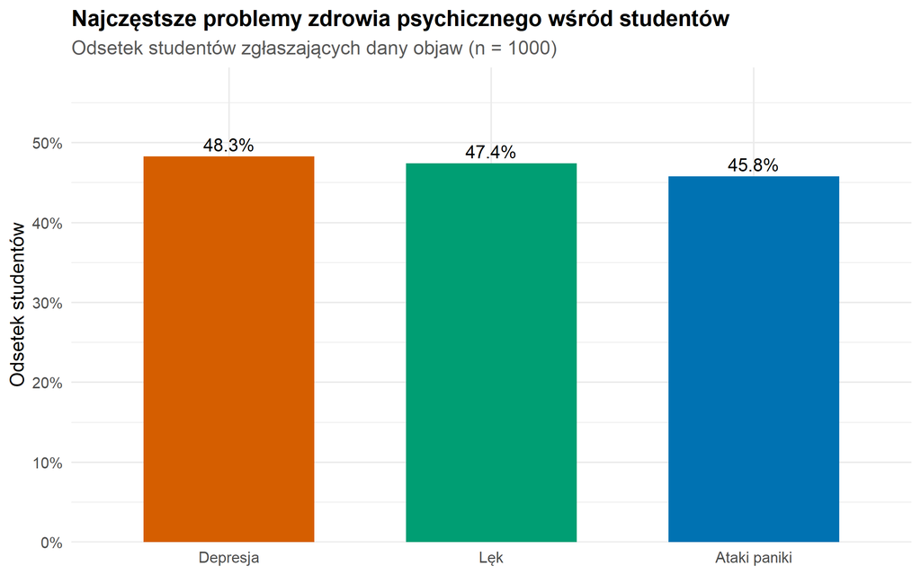

Rysunek 1: Odsetek studentów zgłaszających poszczególne objawy zdrowia psychicznego.

```r
najczestsze_problemy <- mentalhealth_data %>%
  summarise(
    Depresja       = mean(Depression),
    Lęk            = mean(Anxiety),
    `Ataki paniki` = mean(PanicAttack)
  ) %>%
  pivot_longer(everything(), names_to = "Problem", values_to = "Odsetek")

ggplot(najczestsze_problemy,
       aes(x = fct_reorder(Problem, -Odsetek), y = Odsetek, fill = Problem)) +
  geom_col(width = 0.65) +
  geom_text(aes(label = percent(Odsetek, accuracy = 0.1)), vjust = -0.4, size = 4) +
  scale_y_continuous(labels = percent_format(accuracy = 1),
                     limits = c(0, 0.55), expand = expansion(mult = c(0, 0.08))) +
  scale_fill_manual(values = pal_okabe) +
  labs(title = "Najczęstsze problemy zdrowia psychicznego wśród studentów",
       subtitle = "Odsetek studentów zgłaszających dany objaw (n = 1000)",
       x = NULL, y = "Odsetek studentów") +
  guides(fill = "none")
```

Odsetki trzech objawów są do siebie zbliżone: depresja występuje u 48,3% studentów, lęk u 47,4%, a ataki paniki u 45,8%. Najczęstszym objawem jest zatem **depresja**, choć jej przewaga nad pozostałymi jest niewielka.

## 2. Czy kobiety są bardziej narażone na problemy zdrowia psychicznego niż mężczyźni?

Ponieważ próba jest niezrównoważona (760 kobiet vs 240 mężczyzn), porównanie liczb bezwzględnych byłoby mylące: słupki kobiet byłyby wyższe wyłącznie z powodu liczebności. Porównuję więc **odsetki** objawów w obrębie każdej płci i dodatkowo sprawdzam istotność różnic **testem chi-kwadrat**.

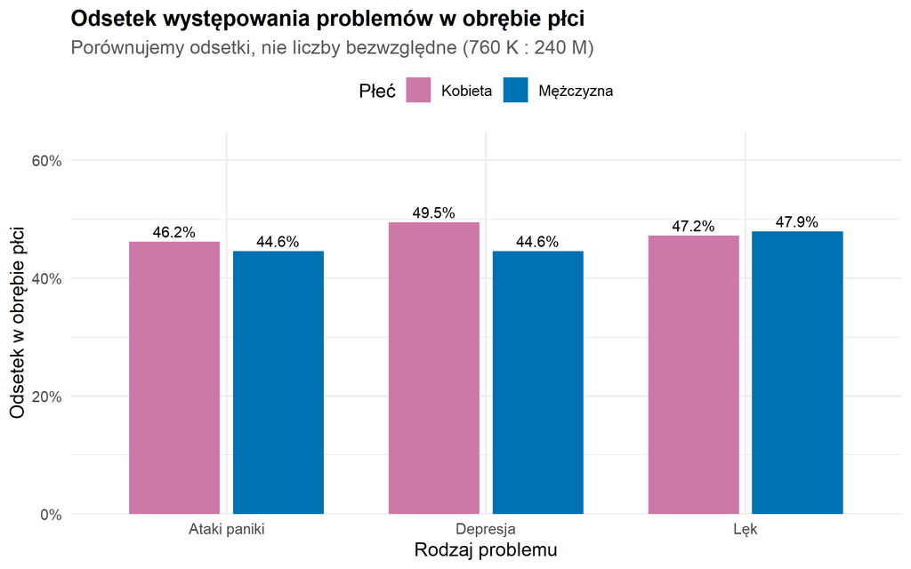

Rysunek 2: Odsetek występowania objawów w obrębie każdej płci (porównanie odsetków, nie liczb bezwzględnych).

```r
odsetki_plci <- mentalhealth_data %>%
  select(Płeć = Gender, Depresja = Depression, Lęk = Anxiety, `Ataki paniki` = PanicAttack) %>%
  pivot_longer(-Płeć, names_to = "Problem", values_to = "x") %>%
  group_by(Płeć, Problem) %>%
  summarise(Odsetek = mean(x), .groups = "drop")

ggplot(odsetki_plci, aes(x = Problem, y = Odsetek, fill = Płeć)) +
  geom_col(position = position_dodge(0.8), width = 0.7) +
  geom_text(aes(label = percent(Odsetek, accuracy = 0.1)),
            position = position_dodge(0.8), vjust = -0.4, size = 3.4) +
  scale_y_continuous(labels = percent_format(accuracy = 1),
                     limits = c(0, 0.6), expand = expansion(mult = c(0, 0.08))) +
  scale_fill_manual(values = c("Kobieta" = "#CC79A7", "Mężczyzna" = "#0072B2")) +
  labs(title = "Odsetek występowania problemów w obrębie płci",
       subtitle = "Porównujemy odsetki, nie liczby bezwzględne (760 K : 240 M)",
       x = "Rodzaj problemu", y = "Odsetek w obrębie płci", fill = "Płeć")
```

```r
problemy <- c(Depresja = "Depression", Lęk = "Anxiety", `Ataki paniki` = "PanicAttack")

testy_plci <- lapply(names(problemy), function(lab) {
  v <- problemy[[lab]]
  r <- tapply(mentalhealth_data[[v]], mentalhealth_data$Gender, mean)
  p <- suppressWarnings(
    chisq.test(table(mentalhealth_data$Gender, mentalhealth_data[[v]]))$p.value)
  tibble::tibble(
    Problem            = lab,
    `Kobiety`          = percent(r[["Kobieta"]],   accuracy = 0.1),
    `Mężczyźni`        = percent(r[["Mężczyzna"]], accuracy = 0.1),
    `p (chi-kwadrat)`  = round(p, 3),
    `Istotne (p<0,05)` = ifelse(p < 0.05, "tak", "nie")
  )
}) %>% bind_rows()

kable(testy_plci,
      caption = "Odsetek objawów w obrębie płci oraz test istotności różnic (chi-kwadrat)") %>%
  kable_styling(bootstrap_options = c("striped", "hover"), full_width = FALSE)
```

Odsetek objawów w obrębie płci oraz test istotności różnic (chi-kwadrat)

| Problem | Kobiety | Mężczyźni | p (chi-kwadrat) | Istotne (p<0,05) |
| --- | --- | --- | --- | --- |
| Depresja | 49.5% | 44.6% | 0.212 | nie |
| Lęk | 47.2% | 47.9% | 0.913 | nie |
| Ataki paniki | 46.2% | 44.6% | 0.719 | nie |

## 3. Jak wiek wiąże się z występowaniem problemów psychicznych?

Aby uczciwie porównać roczniki wieku o różnej liczebności, pokazuję **odsetek** studentów z danym objawem w każdym roczniku (a nie liczby bezwzględne).

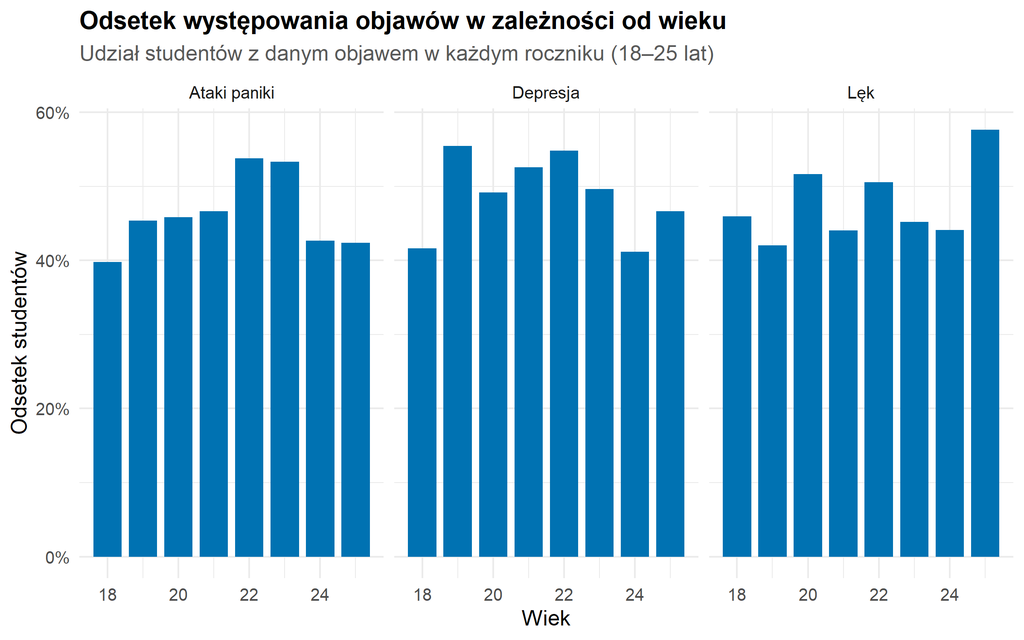

Rysunek 3: Odsetek występowania objawów w zależności od wieku studenta.

```r
wiek_odsetki <- mentalhealth_data %>%
  select(Wiek = Age, Depresja = Depression, Lęk = Anxiety, `Ataki paniki` = PanicAttack) %>%
  pivot_longer(-Wiek, names_to = "Problem", values_to = "x") %>%
  group_by(Problem, Wiek) %>%
  summarise(Odsetek = mean(x), .groups = "drop")

ggplot(wiek_odsetki, aes(x = Wiek, y = Odsetek)) +
  geom_col(fill = "#0072B2", width = 0.8) +
  facet_wrap(~ Problem) +
  scale_y_continuous(labels = percent_format(accuracy = 1)) +
  labs(title = "Odsetek występowania objawów w zależności od wieku",
       subtitle = "Udział studentów z danym objawem w każdym roczniku (18–25 lat)",
       x = "Wiek", y = "Odsetek studentów")
```

## 4. Czy liczba godzin nauki w tygodniu wiąże się z poziomem stresu?

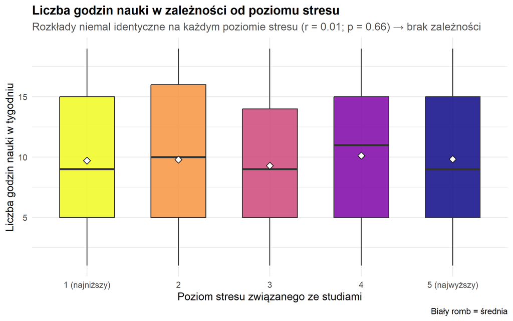

Rysunek 4: Rozkład liczby godzin nauki w zależności od poziomu stresu (boxplot; biały romb = średnia).

```r
r_godziny_stres <- cor(mentalhealth_data$StudyHoursPerWeek,
                       mentalhealth_data$StudyStressLevel)
p_godziny_stres <- cor.test(mentalhealth_data$StudyHoursPerWeek,
                            mentalhealth_data$StudyStressLevel)$p.value

ggplot(mentalhealth_data, aes(x = Stres_f, y = StudyHoursPerWeek, fill = Stres_f)) +
  geom_boxplot(width = 0.6, alpha = 0.85, outlier.alpha = 0.25) +
  stat_summary(fun = mean, geom = "point", shape = 23,
               size = 2.6, fill = "white", color = "black") +
  scale_fill_viridis_d(option = "C", direction = -1) +
  labs(title = "Liczba godzin nauki w zależności od poziomu stresu",
       subtitle = sprintf("Rozkłady niemal identyczne na każdym poziomie stresu (r = %.2f; p = %.2f) → brak zależności",
                           r_godziny_stres, p_godziny_stres),
       x = "Poziom stresu związanego ze studiami",
       y = "Liczba godzin nauki w tygodniu",
       caption = "Biały romb = średnia") +
  guides(fill = "none")
```

Mediany i rozstępy międzykwartylowe liczby godzin nauki są niemal identyczne na wszystkich pięciu poziomach stresu: pudełka leżą na tej samej wysokości, a średnie (białe romby) praktycznie się pokrywają. Potwierdza to współczynnik korelacji Pearsona, który wynosi **r ≈ 0,01** (cor.test, p = 0,66), czyli praktycznie zero. Wniosek: w tych danych liczba godzin nauki **nie wiąże się** z deklarowanym poziomem stresu.

## 5. Czy kierunek studiów wiąże się z jakością snu i poziomem stresu?

**Uwaga metodologiczna.** Kolumna `Course` zawiera 48 nieujednoliconych wartości, z których wiele ma bardzo małą liczebność. Aby odsetki w obrębie kierunku były wiarygodne, najpierw uporządkowałam nazwy kierunków, a następnie ograniczyłam wykresy do kierunków o liczebności **n ≥ 20** (akronimy jak BCS, BIT, KOE zostają wielkimi literami). Skala jakości snu: 1 = bardzo zła, 5 = bardzo dobra; skala stresu: 1 = niski, 5 = wysoki.

```r
dane_kierunki <- courses_min_n(mentalhealth_data, 20)
```

### Jakość snu

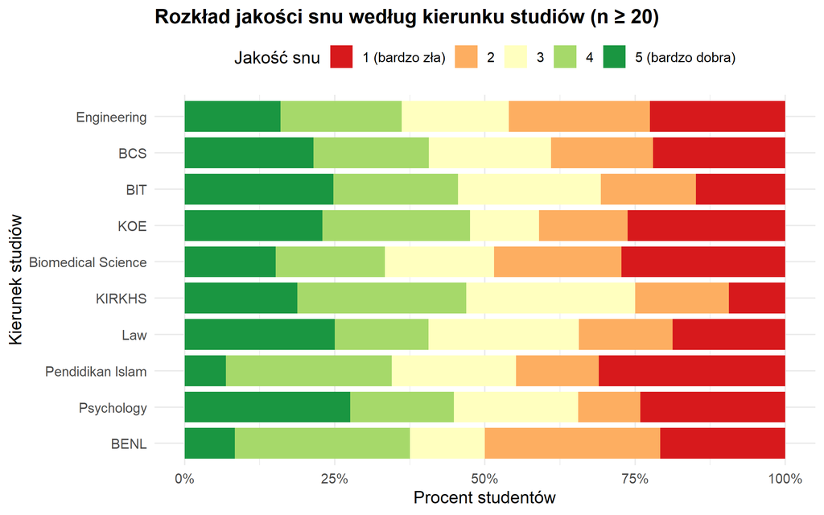

Rysunek 5: Procentowy rozkład jakości snu według kierunku studiów (kierunki o liczebności n ≥ 20).

```r
ggplot(dane_kierunki,
       aes(x = fct_rev(fct_infreq(Course_clean)), fill = Sen_f)) +
  geom_bar(position = "fill", width = 0.85) +
  coord_flip() +
  scale_y_continuous(labels = percent_format(accuracy = 1)) +
  scale_fill_brewer(palette = "RdYlGn") +
  labs(title = "Rozkład jakości snu według kierunku studiów (n ≥ 20)",
       x = "Kierunek studiów", y = "Procent studentów", fill = "Jakość snu")
```

Po uporządkowaniu nazw kierunków i ograniczeniu do kierunków o wystarczającej liczebności widać pewne zróżnicowanie udziału poszczególnych ocen jakości snu. Różnice te należy jednak interpretować **ostrożnie**: zmienna `SleepQuality` ma w całym zbiorze rozkład zbliżony do jednostajnego, więc obserwowane wahania mogą wynikać z losowości próby. Na tej podstawie nie można jednoznacznie stwierdzić, że kierunek studiów determinuje jakość snu.

### Poziom stresu

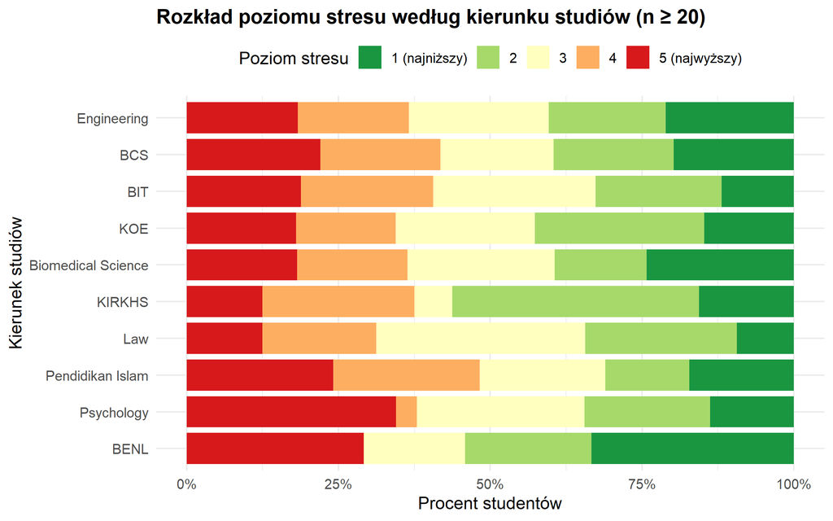

Rysunek 6: Procentowy rozkład poziomu stresu według kierunku studiów (kierunki o liczebności n ≥ 20).

```r
ggplot(dane_kierunki,
       aes(x = fct_rev(fct_infreq(Course_clean)), fill = Stres_f)) +
  geom_bar(position = "fill", width = 0.85) +
  coord_flip() +
  scale_y_continuous(labels = percent_format(accuracy = 1)) +
  scale_fill_brewer(palette = "RdYlGn", direction = -1) +
  labs(title = "Rozkład poziomu stresu według kierunku studiów (n ≥ 20)",
       x = "Kierunek studiów", y = "Procent studentów", fill = "Poziom stresu")
```

Również w przypadku poziomu stresu między kierunkami widać wahania udziału poszczególnych ocen. Podobnie jak przy jakości snu, zmienna `StudyStressLevel` ma rozkład bliski jednostajnemu, a liczebności kierunków są ograniczone, dlatego różnic tych **nie traktuję jako stabilnej prawidłowości**. Mocniejsze wnioski wymagałyby większej liczby obserwacji w obrębie poszczególnych kierunków.

## 6. Jak liczba godzin nauki wpływa na średnią ocen (CGPA)?

CGPA (Cumulative Grade Point Average) to skumulowana średnia ocen. Na uczelniach służy do mierzenia ogólnych osiągnięć akademickich studenta na podstawie ocen A, B, C, D lub F.

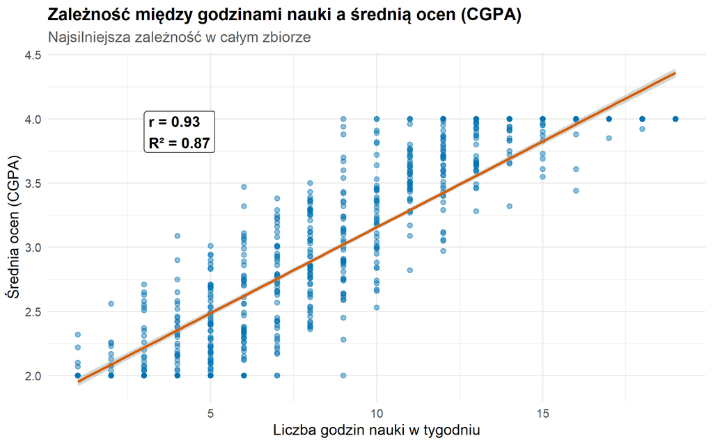

Rysunek 7: Zależność między liczbą godzin nauki a średnią ocen (CGPA) z linią regresji liniowej.

```r
model_cgpa <- lm(CGPA ~ StudyHoursPerWeek, data = mentalhealth_data)
r_cgpa     <- cor(mentalhealth_data$StudyHoursPerWeek, mentalhealth_data$CGPA)
r2_cgpa    <- summary(model_cgpa)$r.squared

ggplot(mentalhealth_data, aes(x = StudyHoursPerWeek, y = CGPA)) +
  geom_point(color = "#0072B2", alpha = 0.45) +
  geom_smooth(method = "lm", se = TRUE, color = "#D55E00") +
  annotate("label", x = 3, y = 3.9, hjust = 0, fill = "white", label.size = 0,
           label = sprintf("r = %.2f\nR² = %.2f", r_cgpa, r2_cgpa), fontface = "bold") +
  labs(title = "Zależność między godzinami nauki a średnią ocen (CGPA)",
       subtitle = "Najsilniejsza zależność w całym zbiorze",
       x = "Liczba godzin nauki w tygodniu", y = "Średnia ocen (CGPA)")
```

```r
ct6 <- cor.test(mentalhealth_data$StudyHoursPerWeek, mentalhealth_data$CGPA)
kable(tibble::tibble(
  Miara   = c("Pearson r", "p (cor.test)", "Nachylenie (slope)", "R²"),
  Wartość = c(round(unname(ct6$estimate), 3),
              format.pval(ct6$p.value, eps = 2.2e-16),
              round(unname(coef(model_cgpa)[2]), 3),
              round(r2_cgpa, 3))
), caption = "Q6: StudyHoursPerWeek vs CGPA, statystyki") %>%
  kable_styling(bootstrap_options = c("striped", "hover"), full_width = FALSE)
```

Q6: StudyHoursPerWeek vs CGPA, statystyki

| Miara | Wartość |
| --- | --- |
| Pearson r | 0.932 |
| p (cor.test) | < 2.2e-16 |
| Nachylenie (slope) | 0.134 |
| R² | 0.869 |

Zależność jest dodatnia i **bardzo silna**: współczynnik korelacji Pearsona wynosi **r = 0,93** (p < 2,2e-16), a model liniowy `CGPA ~ StudyHoursPerWeek` daje **R² ≈ 0,87**: liczba godzin nauki wyjaśnia ok. 87% zmienności CGPA. Każda dodatkowa godzina nauki tygodniowo wiąże się ze wzrostem CGPA o ok. 0,13 punktu. Należy jednak pamiętać, że korelacja oznacza współwystępowanie, a nie związek przyczynowy, a tak wysoka wartość r jest nietypowa dla rzeczywistych danych akademickich i może wynikać ze sposobu wygenerowania tego zbioru.

## 7. Czy studenci ze wsparciem psychologicznym rzadziej doświadczają ataków paniki?

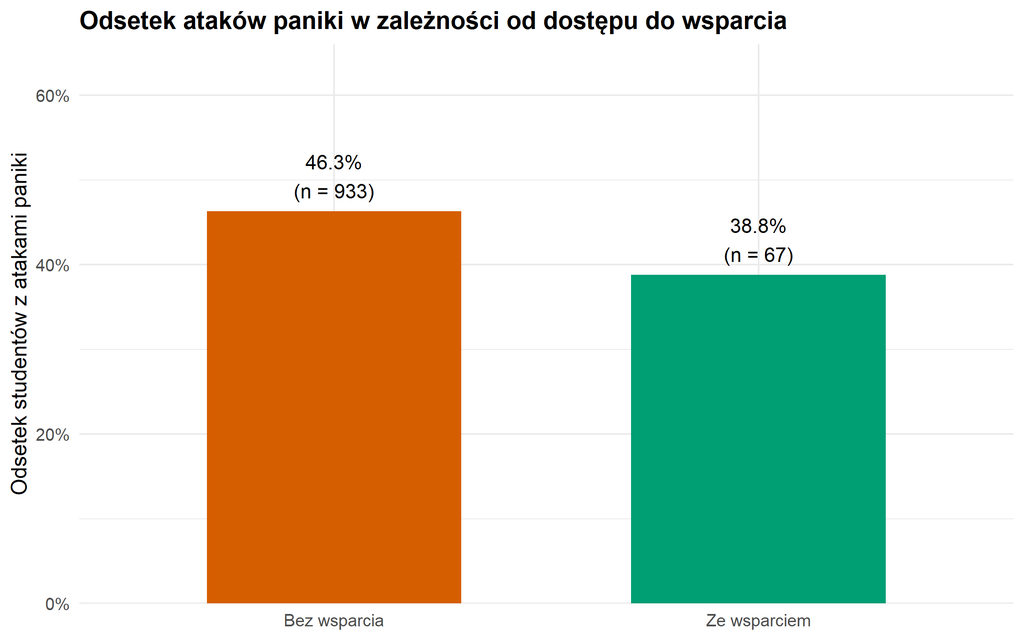

Rysunek 8: Odsetek studentów z atakami paniki w zależności od dostępu do wsparcia psychologicznego.

```r
wsparcie_panika <- mentalhealth_data %>%
  group_by(Wsparcie_f) %>%
  summarise(n = n(), Odsetek = mean(PanicAttack), .groups = "drop")

ggplot(wsparcie_panika, aes(x = Wsparcie_f, y = Odsetek, fill = Wsparcie_f)) +
  geom_col(width = 0.6) +
  geom_text(aes(label = sprintf("%s\n(n = %d)", percent(Odsetek, accuracy = 0.1), n)),
            vjust = -0.3, size = 4) +
  scale_y_continuous(labels = percent_format(accuracy = 1),
                     limits = c(0, 0.6), expand = expansion(mult = c(0, 0.1))) +
  scale_fill_manual(values = c("Bez wsparcia" = "#D55E00", "Ze wsparciem" = "#009E73")) +
  labs(title = "Odsetek ataków paniki w zależności od dostępu do wsparcia",
       x = NULL, y = "Odsetek studentów z atakami paniki") +
  guides(fill = "none")
```

```r
p_wsparcie <- suppressWarnings(
  chisq.test(table(mentalhealth_data$HasMentalHealthSupport,
                   mentalhealth_data$PanicAttack))$p.value)
cat(sprintf("Test chi-kwadrat (wsparcie × ataki paniki): p = %.2f\n", p_wsparcie))
```

```
#> Test chi-kwadrat (wsparcie × ataki paniki): p = 0.29
```

Odsetek ataków paniki w obrębie każdej grupy wynosi **46,3%** wśród studentów bez wsparcia (n = 933) oraz **38,8%** wśród studentów ze wsparciem (n = 67). Kierunek różnicy jest zgodny z intuicją, jednak różnica **nie jest istotna statystycznie** (test chi-kwadrat, p = 0,29), a grupa korzystająca ze wsparcia liczy zaledwie 67 osób, więc jej odsetek obarczony jest dużą niepewnością. Dane **nie dają podstaw**, by twierdzić, że wsparcie psychologiczne realnie zmniejsza częstość ataków paniki.

## 8. Czy dostęp do wsparcia psychologicznego różni się w zależności od kierunku studiów?

Tak jak w pytaniu 5, analizę opieram na uporządkowanej zmiennej `Course_clean` i ograniczam ją do kierunków o liczebności n ≥ 20 (przy nielicznych kierunkach odsetki bywają skrajne (0% lub 100%) wyłącznie z powodu małej próby). Dodatkowo wsparcie deklaruje w całym zbiorze tylko 6,7% studentów.

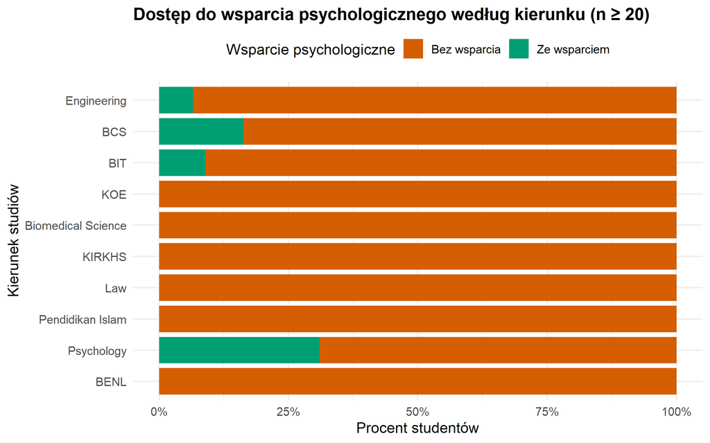

Rysunek 9: Procentowy dostęp do wsparcia psychologicznego według kierunku studiów (kierunki o liczebności n ≥ 20).

```r
ggplot(dane_kierunki,
       aes(x = fct_rev(fct_infreq(Course_clean)), fill = Wsparcie_f)) +
  geom_bar(position = "fill", width = 0.85) +
  coord_flip() +
  scale_y_continuous(labels = percent_format(accuracy = 1)) +
  scale_fill_manual(values = c("Bez wsparcia" = "#D55E00", "Ze wsparciem" = "#009E73")) +
  labs(title = "Dostęp do wsparcia psychologicznego według kierunku (n ≥ 20)",
       x = "Kierunek studiów", y = "Procent studentów", fill = "Wsparcie psychologiczne")
```

## 9. Korelacje między zmiennymi ilościowymi

Aby zbadać zależności między zmiennymi ilościowymi, obliczam macierz korelacji Pearsona dla CGPA, poziomu stresu, liczby godzin nauki, jakości snu oraz zaangażowania akademickiego. Wartości liczbowe wyświetlam wprost, a na wykresie pomijam korelacje nieistotne statystycznie.

```r
zmienne_kor <- mentalhealth_data %>%
  select(CGPA, StudyStressLevel, StudyHoursPerWeek, SleepQuality, AcademicEngagement)
macierz_kor <- cor(zmienne_kor)

kable(round(macierz_kor, 3), caption = "Macierz korelacji Pearsona") %>%
  kable_styling(bootstrap_options = c("striped", "hover"), full_width = FALSE)
```

Macierz korelacji Pearsona

|  | CGPA | StudyStressLevel | StudyHoursPerWeek | SleepQuality | AcademicEngagement |
| --- | --- | --- | --- | --- | --- |
| CGPA | 1.000 | 0.028 | 0.932 | 0.047 | 0.152 |
| StudyStressLevel | 0.028 | 1.000 | 0.014 | 0.005 | 0.036 |
| StudyHoursPerWeek | 0.932 | 0.014 | 1.000 | 0.015 | 0.027 |
| SleepQuality | 0.047 | 0.005 | 0.015 | 1.000 | 0.000 |
| AcademicEngagement | 0.152 | 0.036 | 0.027 | 0.000 | 1.000 |

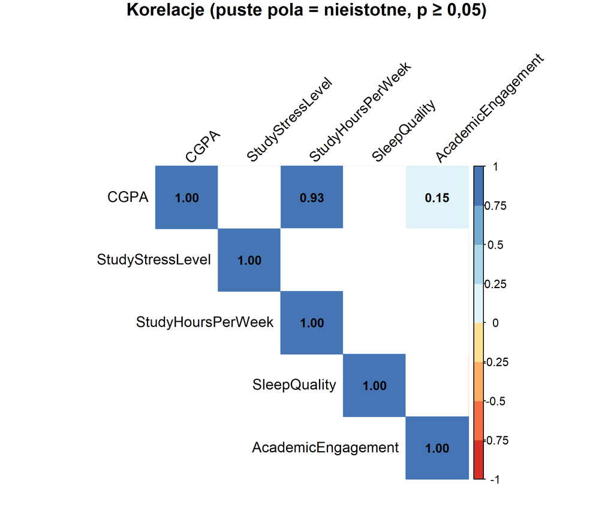

Rysunek 10: Macierz korelacji Pearsona zmiennych ilościowych (puste pola = korelacje nieistotne statystycznie).

```r
p_kor <- cor.mtest(zmienne_kor)$p
corrplot(macierz_kor,
         method = "color", type = "upper", order = "original",
         addCoef.col = "black", number.cex = 0.85,
         p.mat = p_kor, sig.level = 0.05, insig = "blank",
         col = brewer.pal(n = 8, name = "RdYlBu"),
         tl.col = "black", tl.srt = 45,
         mar = c(0, 0, 1, 0),
         title = "Korelacje (puste pola = nieistotne, p ≥ 0,05)")
```

- **Bardzo silna korelacja CGPA ↔︎ StudyHoursPerWeek (r = 0,93):** zdecydowanie najsilniejsza zależność w zbiorze. To ta para, a **nie** poziom stresu, dominuje na wykresie korelacji.
- **Brak związku StudyStressLevel ↔︎ StudyHoursPerWeek (r = 0,01):** wbrew pierwszemu wrażeniu poziom stresu jest praktycznie nieskorelowany z liczbą godzin nauki.
- **Słaba korelacja SleepQuality z resztą (|r| ≤ 0,05):** jakość snu jest niemal nieskorelowana ze wszystkimi pozostałymi zmiennymi; AcademicEngagement ↔︎ CGPA jest tylko słaba (r = 0,15).

*Uwaga metodologiczna:* przy n = 1000 nawet bardzo małe współczynniki bywają „istotne” statystycznie, dlatego o interpretacji decyduje **siła efektu** (wartość r), a nie samo p.